# Ejemplo Advertising

Marcela Svarc

Consideramos el conjunto de datos Advertising, que tiene datos sobre la inversion publicitaria en tres medios TV, Radio y Diario y las ventas en 200 puntos de ventas. Se quiere explicar las ventas a partir de la inversion publicitaria. Estos datos se encuentran en la pagina del libro Introduction to Statistical Learning. Comencemos cargando los datos

```r
advertising= read.csv(file = 'Advertising.csv',header = TRUE)
attach(advertising)
```

A continuacion buscamos las medidas resumenes y hacemos los graficos.

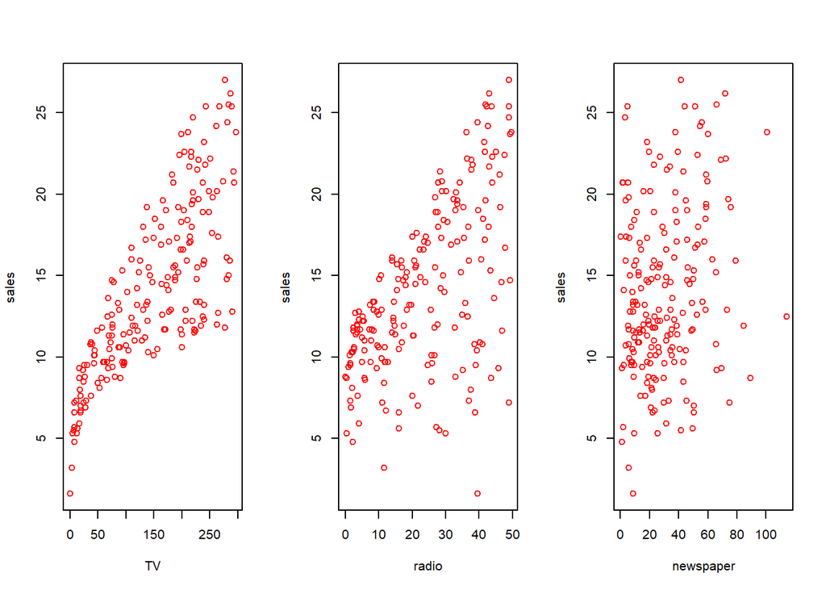

```r
par(mfrow=c(1,3))
plot(TV,sales,col="red")
plot(radio,sales,col="red")
plot(newspaper,sales,col="red")
```

```r
summary(advertising)
```

```
##        X                TV             radio          newspaper
##  Min.   :  1.00   Min.   :  0.70   Min.   : 0.000   Min.   :  0.30
##  1st Qu.: 50.75   1st Qu.: 74.38   1st Qu.: 9.975   1st Qu.: 12.75
##  Median :100.50   Median :149.75   Median :22.900   Median : 25.75
##  Mean   :100.50   Mean   :147.04   Mean   :23.264   Mean   : 30.55
##  3rd Qu.:150.25   3rd Qu.:218.82   3rd Qu.:36.525   3rd Qu.: 45.10
##  Max.   :200.00   Max.   :296.40   Max.   :49.600   Max.   :114.00
##      sales
##  Min.   : 1.60
##  1st Qu.:10.38
##  Median :12.90
##  Mean   :14.02
##  3rd Qu.:17.40
##  Max.   :27.00
```

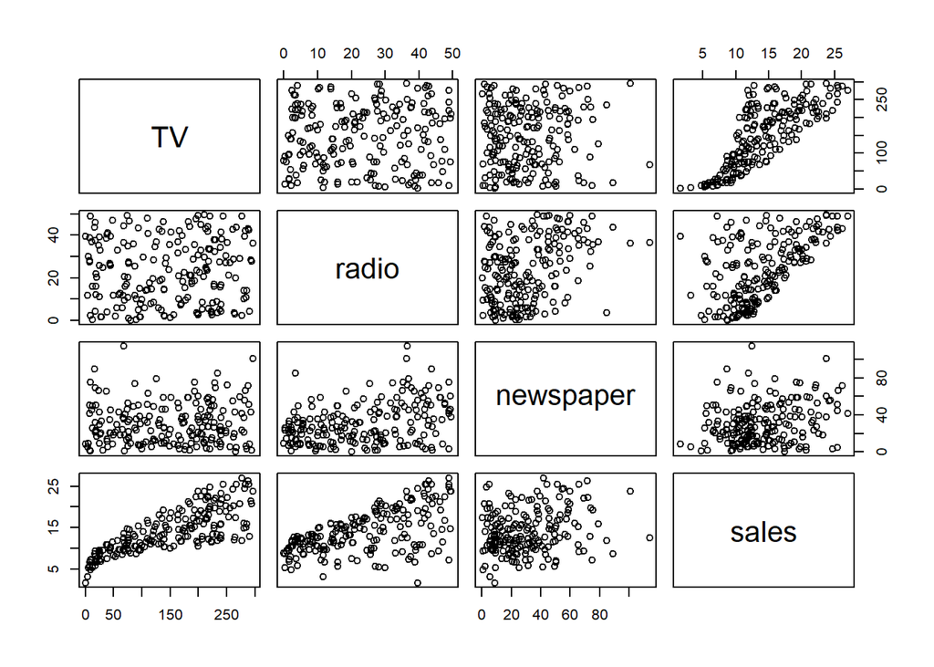

```r
pairs(advertising[,-1])
```

Se puede ver que la inversion publicitaria en TV es la que presenta a simple vista mayor correlacion con las ventas. Que la escala de los montos invertidos en los tres medios difieren. La variabilidad de las ventas aumenta en la medida que aumenta la variabilidad en la inversion publicitaria.

En base a este resultado corremos la regresion utilizando solamente la variable regreso inversion publicitaria en TV.

```r
adv.tv.lm=lm(sales~TV)
summary(adv.tv.lm)
```

```
##
## Call:
## lm(formula = sales ~ TV)
##
## Residuals:
##     Min      1Q  Median      3Q     Max
## -8.3860 -1.9545 -0.1913  2.0671  7.2124
##
## Coefficients:
##             Estimate Std. Error t value Pr(>|t|)
## (Intercept) 7.032594   0.457843   15.36   <2e-16 ***
## TV          0.047537   0.002691   17.67   <2e-16 ***
## ---
## Signif. codes:  0 '***' 0.001 '**' 0.01 '*' 0.05 '.' 0.1 ' ' 1
##
## Residual standard error: 3.259 on 198 degrees of freedom
## Multiple R-squared:  0.6119, Adjusted R-squared:  0.6099
## F-statistic: 312.1 on 1 and 198 DF,  p-value: < 2.2e-16
```

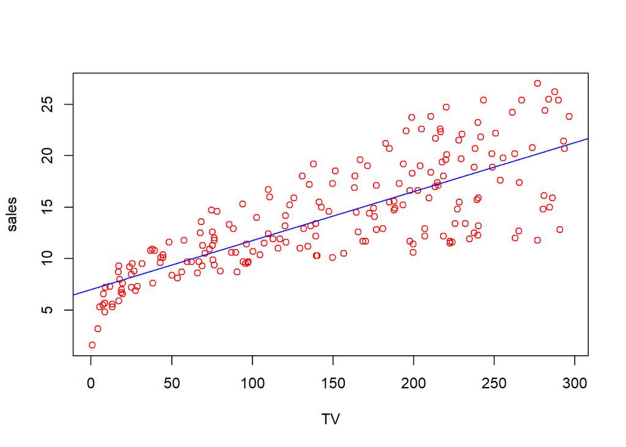

```r
#### Grafico los puntos y la recta ajustada
par(mfrow=c(1,1))
plot(TV,sales,col="red")
abline(adv.tv.lm,col="blue")
```

Los graficos que salen por default correspondientes a la regresion son los siguientes

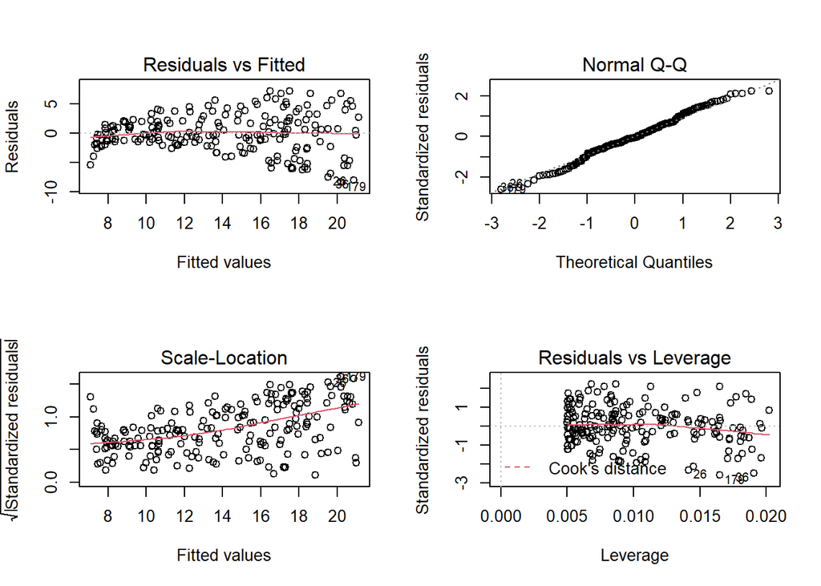

```r
par(mfrow=c(2,2))
plot(adv.tv.lm)
```

Ahora analizamos la relacion entre las variables regresoras

```r
round(cor(advertising[,-1]),3)
```

```
##              TV radio newspaper sales
## TV        1.000 0.055     0.057 0.782
## radio     0.055 1.000     0.354 0.576
## newspaper 0.057 0.354     1.000 0.228
## sales     0.782 0.576     0.228 1.000
```

Vemos que hay una relacion moderada entre la inversion publicitaria en radio y diario. Tambien que es baja entre diario y ventas.

Hacemos la regresion completa

```r
adv.lm=lm(sales~TV+radio+newspaper)
summary(adv.lm)
```

```
##
## Call:
## lm(formula = sales ~ TV + radio + newspaper)
##
## Residuals:
##     Min      1Q  Median      3Q     Max
## -8.8277 -0.8908  0.2418  1.1893  2.8292
##
## Coefficients:
##              Estimate Std. Error t value Pr(>|t|)
## (Intercept)  2.938889   0.311908   9.422   <2e-16 ***
## TV           0.045765   0.001395  32.809   <2e-16 ***
## radio        0.188530   0.008611  21.893   <2e-16 ***
## newspaper   -0.001037   0.005871  -0.177     0.86
## ---
## Signif. codes:  0 '***' 0.001 '**' 0.01 '*' 0.05 '.' 0.1 ' ' 1
##
## Residual standard error: 1.686 on 196 degrees of freedom
## Multiple R-squared:  0.8972, Adjusted R-squared:  0.8956
## F-statistic: 570.3 on 3 and 196 DF,  p-value: < 2.2e-16
```

Esta misma regresion tambien la podemos hacer de otras formas.

```r
adv.lm=lm(sales~.,data=advertising) #siempre aclarar cual es el conjunto de datos.
```

Regresion sin intercept

```r
adv.lm.sinintercept=lm(sales~-1.,data=advertising)
```

Que tiene la salidad del comando lm

```r
names(adv.lm)
```

```
##  [1] "coefficients"  "residuals"     "effects"       "rank"
##  [5] "fitted.values" "assign"        "qr"            "df.residual"
##  [9] "xlevels"       "call"          "terms"         "model"
```

Tambien resulta util quedarse asignar la salida del summary porque permite quedarse con otros estadisticos

```r
adv.lm.sum=summary(adv.lm)
names(adv.lm.sum)
```

```
##  [1] "call"          "terms"         "residuals"     "coefficients"
##  [5] "aliased"       "sigma"         "df"            "r.squared"
##  [9] "adj.r.squared" "fstatistic"    "cov.unscaled"
```

Intervalos de confianza para los estimadores de los parametros $\beta$

```r
cbind(coefficients(adv.lm), confint(adv.lm, level = 0.95))
```

```
##                                  2.5 %     97.5 %
## (Intercept)  3.0052094201  2.227750417 3.78266842
## X           -0.0005798278 -0.004719975 0.00356032
## TV           0.0457759196  0.043017218 0.04853462
## radio        0.1883831760  0.171327646 0.20543871
## newspaper   -0.0012433262 -0.012942222 0.01045557
```

Ahora hacemos test para combinaciones lineales de los parametros

Comparamos los modelos usando las tablas de ANOVA

```r
anova(adv.tv.lm,adv.lm)
```

```
## Analysis of Variance Table
##
## Model 1: sales ~ TV
## Model 2: sales ~ X + TV + radio + newspaper
##   Res.Df     RSS Df Sum of Sq      F    Pr(>F)
## 1    198 2102.53
## 2    195  556.61  3    1545.9 180.53 < 2.2e-16 ***
## ---
## Signif. codes:  0 '***' 0.001 '**' 0.01 '*' 0.05 '.' 0.1 ' ' 1
```

```r
adv.lm.nonews<-lm(sales~TV+radio)
anova(adv.lm.nonews,adv.lm)
```

```
## Analysis of Variance Table
##
## Model 1: sales ~ TV + radio
## Model 2: sales ~ X + TV + radio + newspaper
##   Res.Df    RSS Df Sum of Sq      F Pr(>F)
## 1    197 556.91
## 2    195 556.61  2   0.30648 0.0537 0.9477
```

```r
library(ellipse)
```

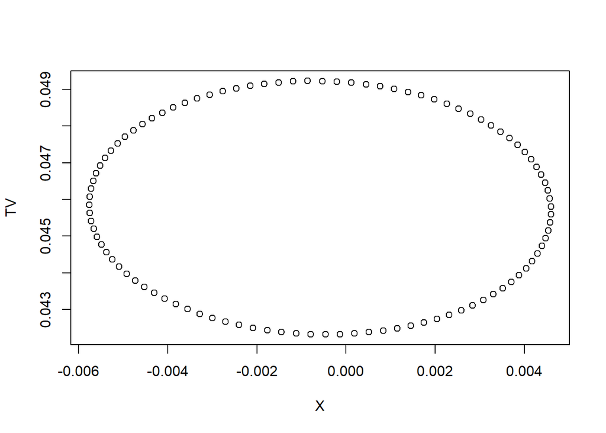

```r
plot(ellipse(adv.lm, which=c(2,3), level=0.95))
```

Podemos ver la matriz de covarianza de los estimadores d elos parametros

```r
round(vcov(adv.lm),2)
```

```
##             (Intercept) X TV radio newspaper
## (Intercept)        0.16 0  0     0         0
## X                  0.00 0  0     0         0
## TV                 0.00 0  0     0         0
## radio              0.00 0  0     0         0
## newspaper          0.00 0  0     0         0
```

Nos quedamos solamente con dos variables TV y radio, para seleccionarlas usamos el criterio de Akaike

```r
step(adv.lm)
```

```
## Start:  AIC=214.71
## sales ~ X + TV + radio + newspaper
##
##             Df Sum of Sq    RSS    AIC
## - newspaper  1      0.13  556.7 212.75
## - X          1      0.22  556.8 212.79
## <none>                    556.6 214.71
## - radio      1   1354.48 1911.1 459.42
## - TV         1   3056.91 3613.5 586.82
##
## Step:  AIC=212.75
## sales ~ X + TV + radio
##
##         Df Sum of Sq    RSS    AIC
## - X      1      0.18  556.9 210.82
## <none>                556.7 212.75
## - radio  1   1522.57 2079.3 474.29
## - TV     1   3060.94 3617.7 585.05
##
## Step:  AIC=210.82
## sales ~ TV + radio
##
##         Df Sum of Sq    RSS    AIC
## <none>                556.9 210.82
## - radio  1    1545.6 2102.5 474.52
## - TV     1    3061.6 3618.5 583.10
```

```
##
## Call:
## lm(formula = sales ~ TV + radio, data = advertising)
##
## Coefficients:
## (Intercept)           TV        radio
##     2.92110      0.04575      0.18799
```

Visualizamos en 3D

```r
library(rgl)
plot3d(TV,radio,sales)
```

Explorar el comando movie para hacer peliculas con las rotaciones

Hacemos ahora la regresion utilizando unicamente las variables TV y radio y visualizamos sus graficos

```r
adv.lm.2=lm(sales~TV+radio)
summary(adv.lm.2)
```

```
##
## Call:
## lm(formula = sales ~ TV + radio)
##
## Residuals:
##     Min      1Q  Median      3Q     Max
## -8.7977 -0.8752  0.2422  1.1708  2.8328
##
## Coefficients:
##             Estimate Std. Error t value Pr(>|t|)
## (Intercept)  2.92110    0.29449   9.919   <2e-16 ***
## TV           0.04575    0.00139  32.909   <2e-16 ***
## radio        0.18799    0.00804  23.382   <2e-16 ***
## ---
## Signif. codes:  0 '***' 0.001 '**' 0.01 '*' 0.05 '.' 0.1 ' ' 1
##
## Residual standard error: 1.681 on 197 degrees of freedom
## Multiple R-squared:  0.8972, Adjusted R-squared:  0.8962
## F-statistic: 859.6 on 2 and 197 DF,  p-value: < 2.2e-16
```

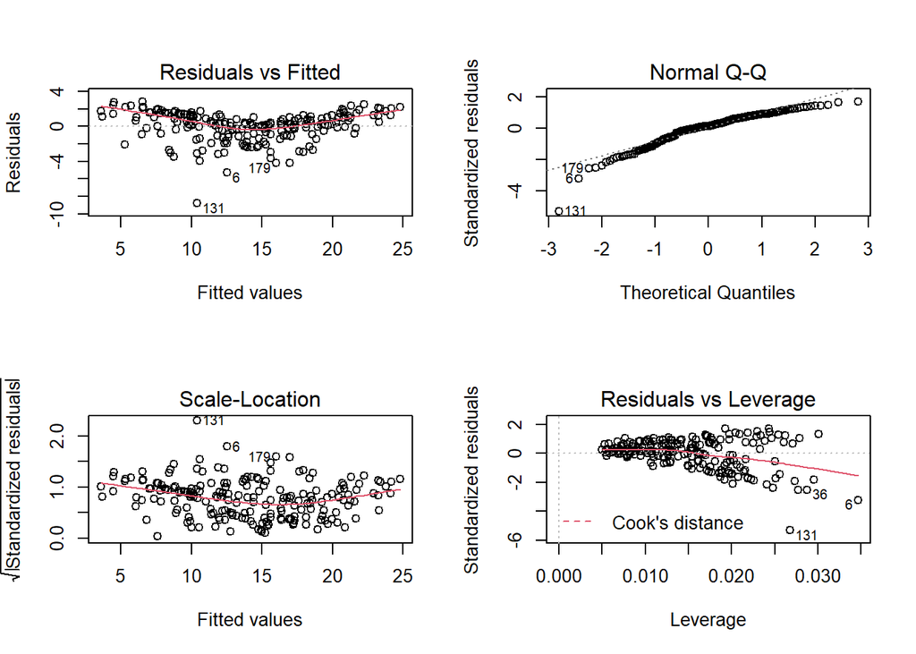

```r
par(mfrow=c(2,2))
plot(adv.lm.2)
```

Calculamos intervalos de confianza y de prediccion para la variable de respuesta.

```r
predict(adv.lm.2, newdata = data.frame(TV=100,radio=20),
                  interval = c("confidence"), level = 0.95)
```

```
##        fit      lwr      upr
## 1 11.25647 10.98525 11.52768
```

```r
predict(adv.lm.2, newdata = data.frame(TV=100,radio=20),
                  interval = c("predict"), level = 0.95)
```

```
##        fit      lwr      upr
## 1 11.25647 7.929616 14.58332
```

Graficamos los residuos estudentizados

```r
library(MASS)
```

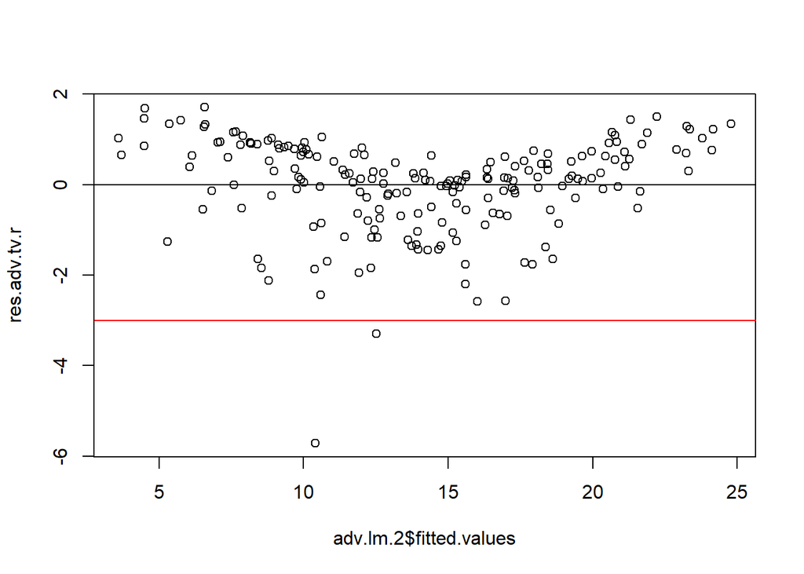

```r
par(mfrow=c(1,1))
res.adv.tv.r=studres(adv.lm.2)
plot(adv.lm.2$fitted.values,res.adv.tv.r)
abline(0,0)
abline(-3,0,col="red")
```

Graficamos los residuos versus las variables resgresoras

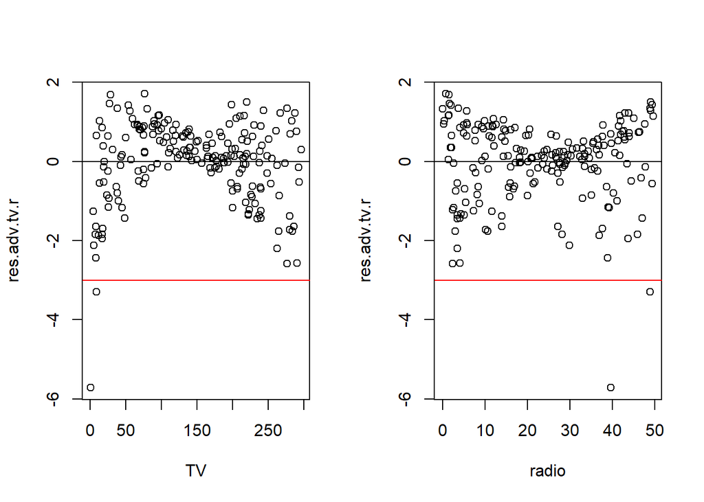

```r
par(mfrow=c(1,2))
plot(TV,res.adv.tv.r)
abline(0,0)
abline(-3,0,col="red")

plot(radio,res.adv.tv.r)
abline(0,0)
abline(-3,0,col="red")
```

La varianza parece ser estable no deberiamos tener que transformar la variable de respuesta, aca se confirma analizando la transformacion de box y cox

```r
ad.lm.bc=boxcox(adv.lm.2)
```

[figure not shown]

Y para analizar las posibles transformaciones en los regresores usamos la transformacion de Box-Tidwell

```r
library(car)
#pide que las variables regresoras sean estrictamente positivas
rad=radio+0.001 #como radio tiene minimo cero la corro un poco
boxTidwell(sales ~ TV + rad) #pide que las variables regresoras sean estrictamente positivas
```

```
##     MLE of lambda Score Statistic (z) Pr(>|z|)
## TV        0.35151             -8.5182   <2e-16 ***
## rad       1.15019              1.5904   0.1117
## ---
## Signif. codes:  0 '***' 0.001 '**' 0.01 '*' 0.05 '.' 0.1 ' ' 1
##
## iterations =  4
```

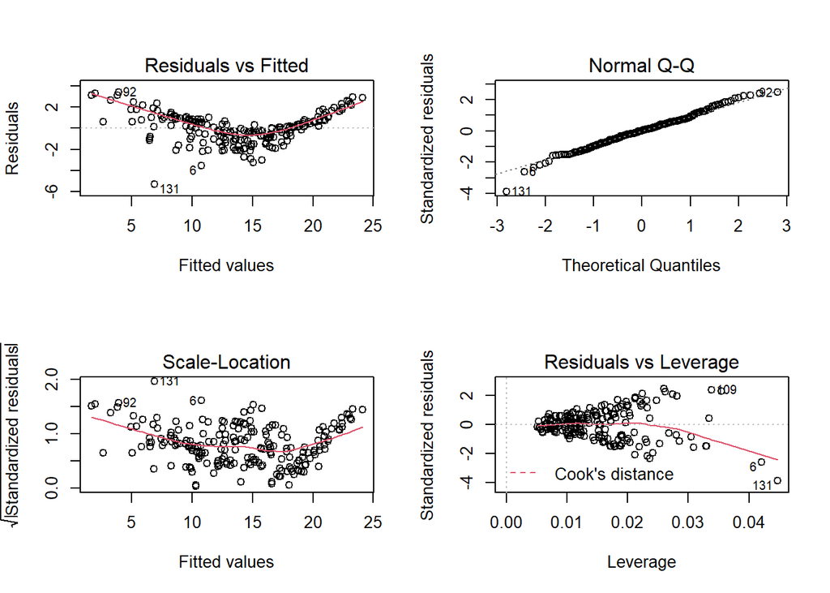

```r
sqTV=sqrt(TV)
adv.lm.3<-lm(sales~sqTV+radio)
par(mfrow=c(2,2))
plot(adv.lm.3)
```

Testeamos si la correlacion entre los errores es positiva

```r
library(lmtest)
dwtest(adv.lm.3)
```

```
##
##  Durbin-Watson test
##
## data:  adv.lm.3
## DW = 2.1294, p-value = 0.8216
## alternative hypothesis: true autocorrelation is greater than 0
```

Analizamos el leverage

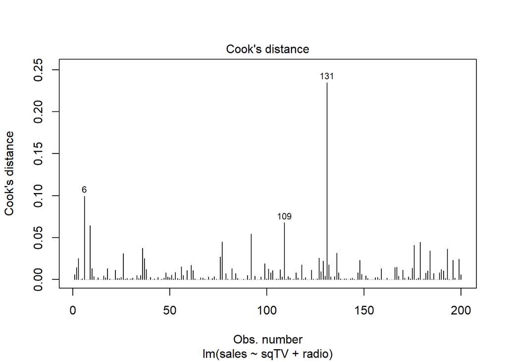

```r
par(mfrow=c(1,1))
plot(adv.lm.3,4)
```

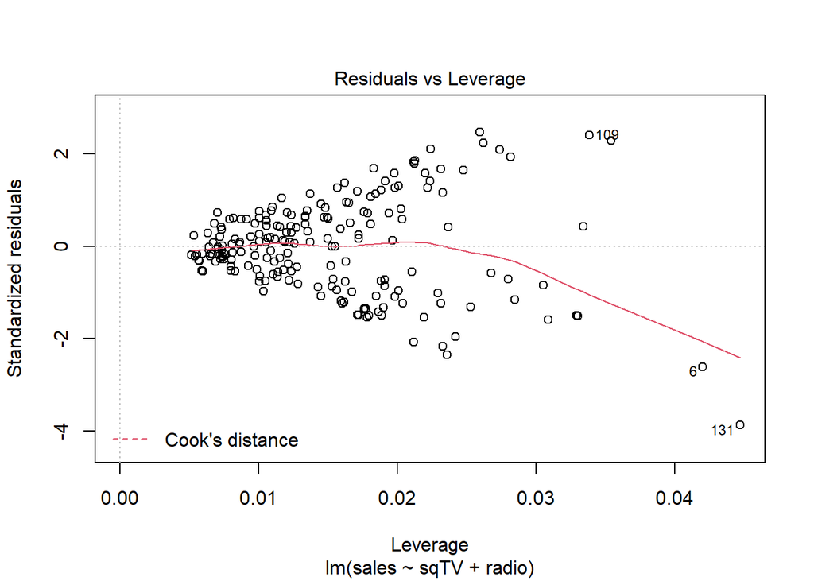

```r
plot(adv.lm.3,5)
```

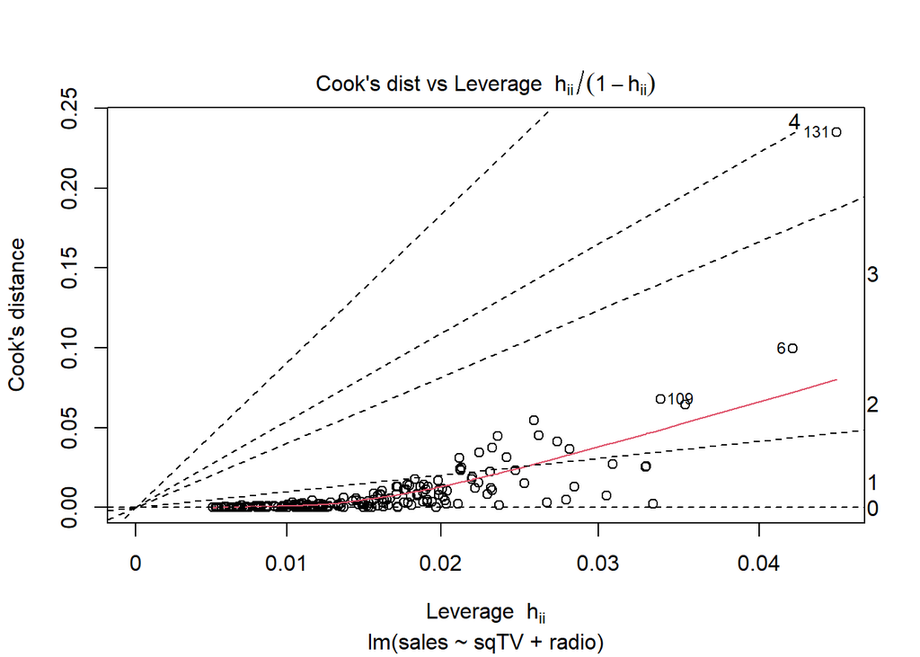

```r
plot(adv.lm.3,6)
```

Calculo las distancias de Cook

```r
which((cooks.distance(adv.lm.3)>pf(3,193,0.5))==TRUE)
```

```
## named integer(0)
```

calculo el leverage

```r
which((hatvalues(adv.lm.3)>(2*3/200))==TRUE)
```

```
##   3   6   9  76  79 109 127 131 156
##   3   6   9  76  79 109 127 131 156
```

Calculamos dffits

```r
which(abs(dffits(adv.lm.3))>(2*sqrt(3/200)))
```

```
##   3   6   9  26  36  37  76  77  92 109 127 129 131 136 148 176 179 184 193 196
##   3   6   9  26  36  37  76  77  92 109 127 129 131 136 148 176 179 184 193 196
## 199
## 199
```

Calculamos Dfbetas

```r
which(abs(dfbetas(adv.lm.3))>(2/sqrt(200)))
```

```
##  [1]   6   9  37  61  77  92  99 107 109 118 127 131 148 176 183 184 190 193 196
## [20] 199 203 206 209 226 236 237 276 277 292 299 307 309 327 331 336 359 367 376
## [39] 379 384 390 393 396 399 403 406 409 410 426 436 437 438 456 459 461 476 477
## [58] 492 499 509 518 529 531 532 536 548 566 575 576 579 584 593 596 599
```

Analizo las interacciones hacerlo con sqTV que funciona muy bien

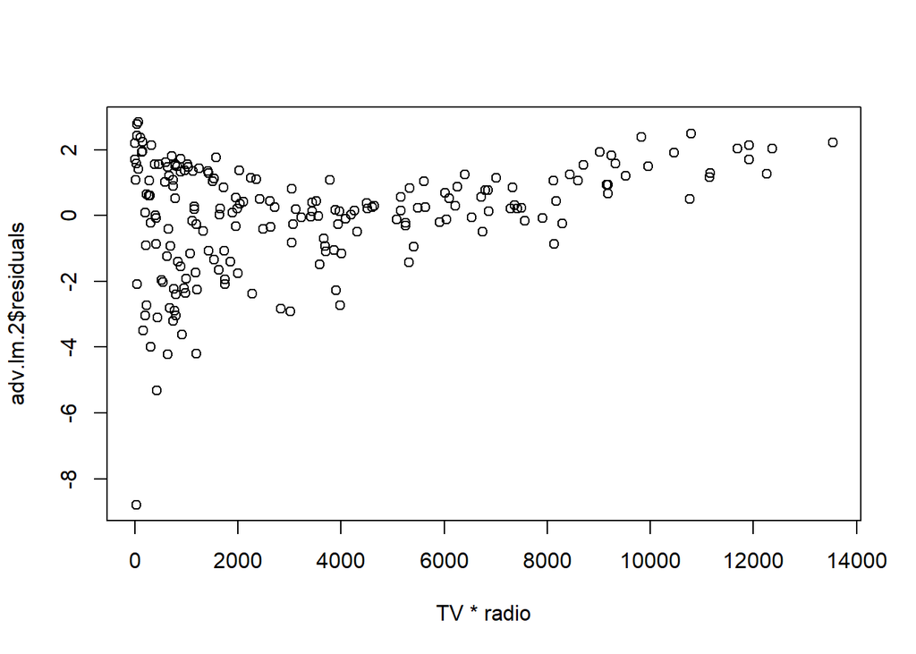

```r
plot(TV*radio,adv.lm.2$residuals)#primero hacer el grafico que me indica que las interacciones
```

```r
adv.lm.4=lm(sales~sqTV*radio)
summary(adv.lm.4)
```

```
##
## Call:
## lm(formula = sales ~ sqTV * radio)
##
## Residuals:
##     Min      1Q  Median      3Q     Max
## -2.0562 -0.2757 -0.0121  0.2758  1.2421
##
## Coefficients:
##               Estimate Std. Error t value Pr(>|t|)
## (Intercept)  4.4444112  0.1793714  24.778  < 2e-16 ***
## sqTV         0.4383960  0.0150223  29.183  < 2e-16 ***
## radio       -0.0500957  0.0062645  -7.997 1.09e-13 ***
## sqTV:radio   0.0215106  0.0005179  41.538  < 2e-16 ***
## ---
## Signif. codes:  0 '***' 0.001 '**' 0.01 '*' 0.05 '.' 0.1 ' ' 1
##
## Residual standard error: 0.4476 on 196 degrees of freedom
## Multiple R-squared:  0.9928, Adjusted R-squared:  0.9926
## F-statistic:  8949 on 3 and 196 DF,  p-value: < 2.2e-16
```

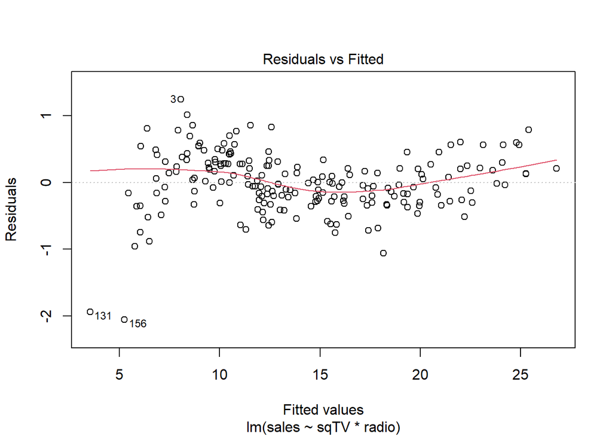

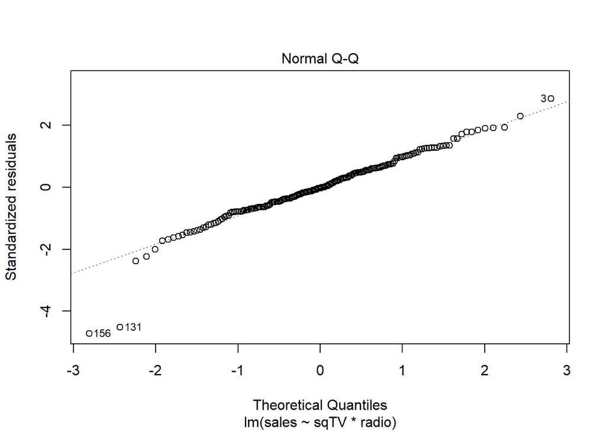

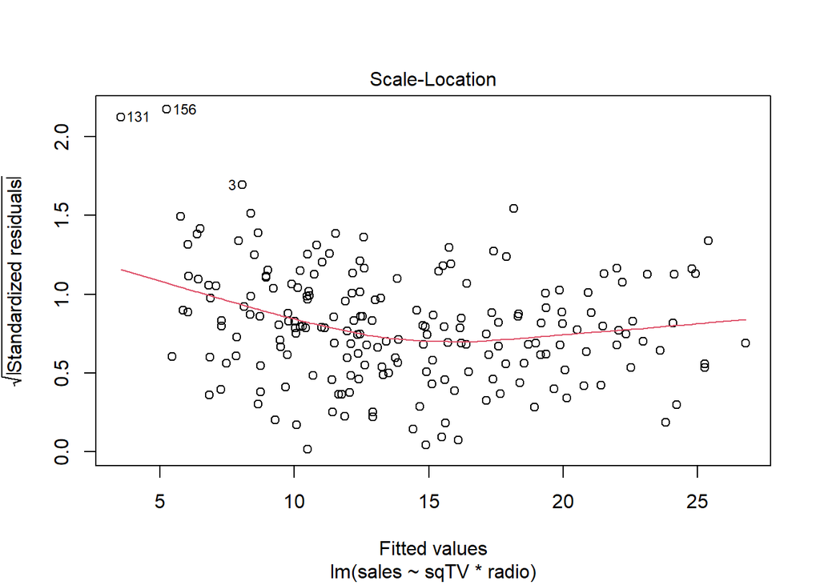

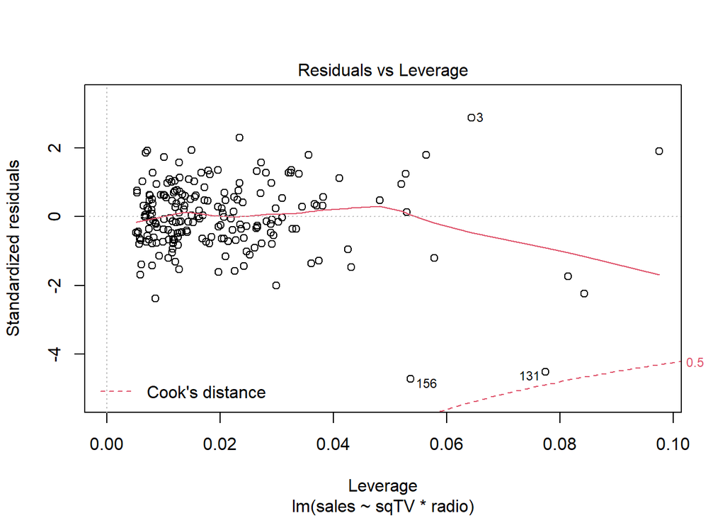

```r
plot(adv.lm.4)
```